# Laptop’s price

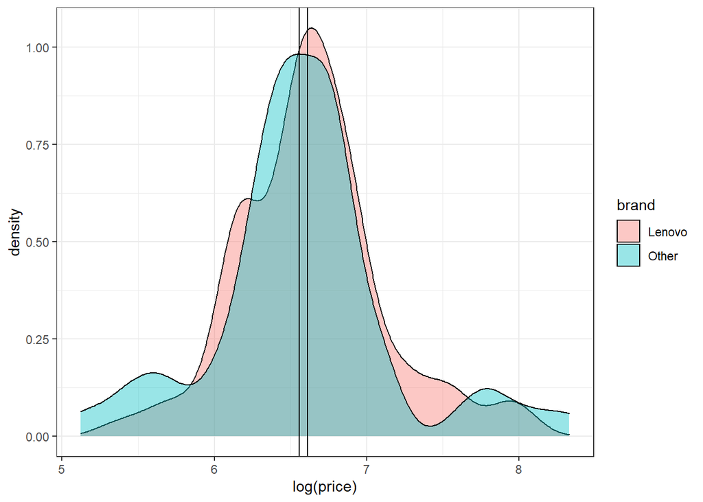

```r
med_br4 <- median(log(df_brand3[df_brand3$brand %in% "Lenovo", ]$price))
ggplot(df_brand3, aes(fill=brand, x=log(price))) + geom_density(alpha=0.4) + geom_vline(aes(xintercept=med_br1)) + geom_vline(aes(xintercept=med_br4))+ theme_bw()
```

The “Other” laptop price distribution look similar to HP, Lenovo and Acer distributions for the price.

HP and Acer have a closer median to Other, but Lenovo density looks much similar to Other’s.

Acer and HP’s dentisy are very alike.

```r
df_brand0 <-df_brand[df_brand$brand %in% c("Lenovo", "Other", "acer", "HP"),]
kruskal.test(df_brand0$price ~ df_brand0$brand)
```

```
##
##  Kruskal-Wallis rank sum test
##
## data:  df_brand0$price by df_brand0$brand
## Kruskal-Wallis chi-squared = 1.0054, df = 3, p-value = 0.7999
```

The medians for this 4 categories are very similar (statistically, there is no difference). I will group the 4 of them together as Lenovo_HP_Acer_Other

```r
# Before
table(df_gr$brand)
```

```
##
##   ASUS   DELL Lenovo     HP  Other   acer    MSI  APPLE
##    254    154    148    142     60     58     52     28
```

```r
df_gr$brand <- fct_collapse(df_gr$brand, Lenovo_HP_Acer_Other = c("acer", "HP", "Other", "Lenovo"))
df_gr$brand <- fct_infreq(df_gr$brand)
# After
table(df_gr$brand)
```

```
##
## Lenovo_HP_Acer_Other                 ASUS                 DELL
##                  408                  254                  154
##                  MSI                APPLE
##                   52                   28
```

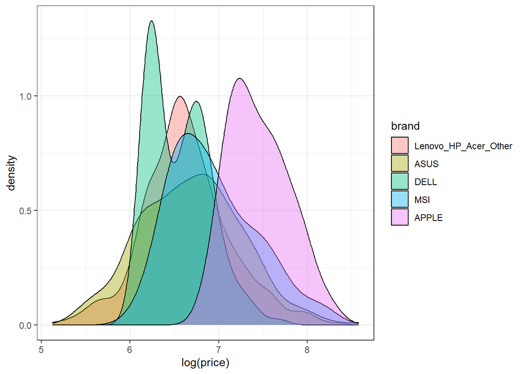

```r
ggplot(df_gr, aes(fill=brand, x=log(price))) + geom_density(alpha=0.4) + theme_bw()
```

# 7 Multivariant qualitative (MCA/DCA)

Since all the independent variables to explain the price are categorical, I can do multiple correspondence analysis to see how the variables and their classes are related.

```r
data_mca <- df_gr[, !names(df_gr) %in%
                       c("processor_brand", "warranty", "msoffice")]
res.MCA <- MCA(data_mca, quanti.sup=1, quali.sup=c(5,6)
               , graph=F
               ) # method="Burt" gives CA on Burt table

t(res.MCA$eig)
```

```
##                                        dim 1      dim 2      dim 3      dim 4
## eigenvalue                         0.5111218  0.3722007  0.2989747  0.2796873
## percentage of variance            17.0373925 12.4066885  9.9658220  9.3229102
## cumulative percentage of variance 17.0373925 29.4440810 39.4099030 48.7328131
##                                       dim 5      dim 6      dim 7      dim 8
## eigenvalue                         0.265139  0.2493878  0.2239862  0.2086314
## percentage of variance             8.837967  8.3129253  7.4662065  6.9543812
## cumulative percentage of variance 57.570780 65.8837056 73.3499121 80.3042934
##                                       dim 9     dim 10     dim 11       dim 12
## eigenvalue                         0.187285  0.1859163  0.1224881   0.09518182
## percentage of variance             6.242833  6.1972089  4.0829372   3.17272729
## cumulative percentage of variance 86.547127 92.7443355 96.8272727 100.00000000
```

**Visualizing the first 2 dimensions**

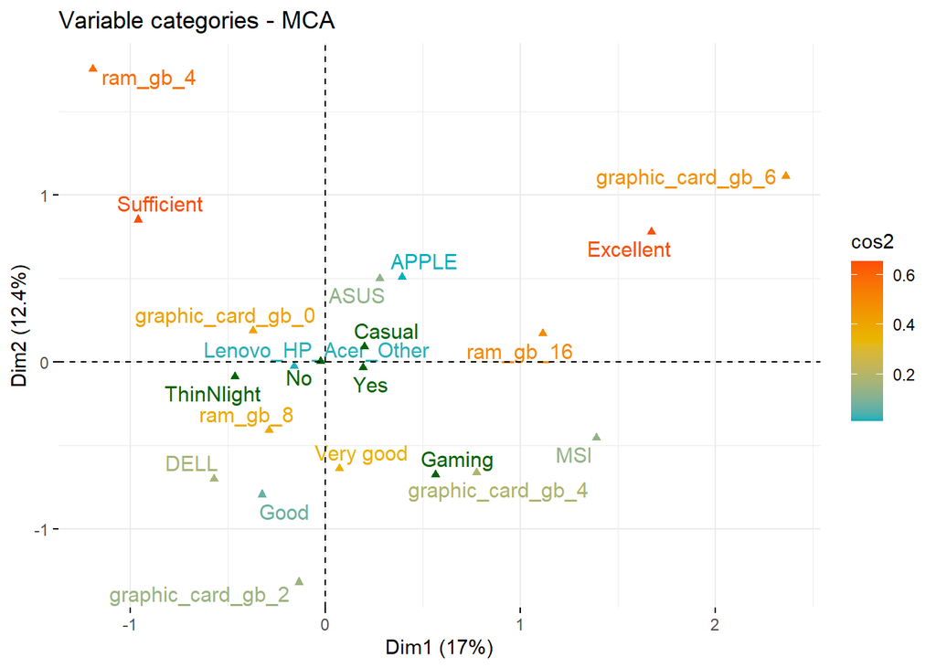

```r
fviz_mca_var(res.MCA, col.var="cos2", gradient.cols = c("#00AFBB", "#E7B800", "#FC4E07"),
               repel = TRUE,
               ggtheme = theme_minimal())
```

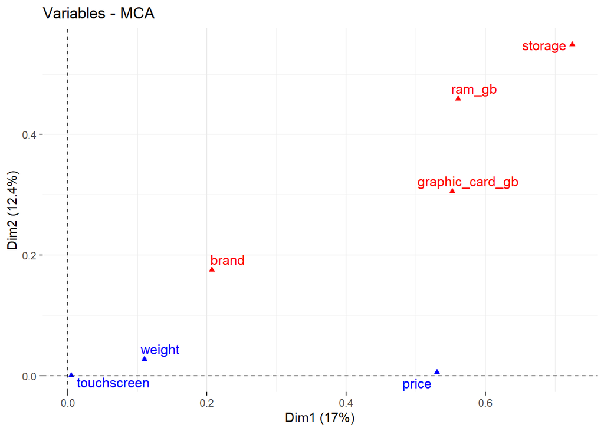

```r
fviz_mca_var(res.MCA, choice = "mca.cor",
            repel = TRUE, # Avoid text overlapping (slow)
            ggtheme = theme_minimal())
```

Looking at the second graph, Price has a medium positive correlation with dimension 1.

This means that classes from categorical attributes that have correlation with this dimension (plot 1) will be related to the price as well. Per instance, a laptop with Excellent storage, 6GB graphic card and 16GB RAM will have higher price.

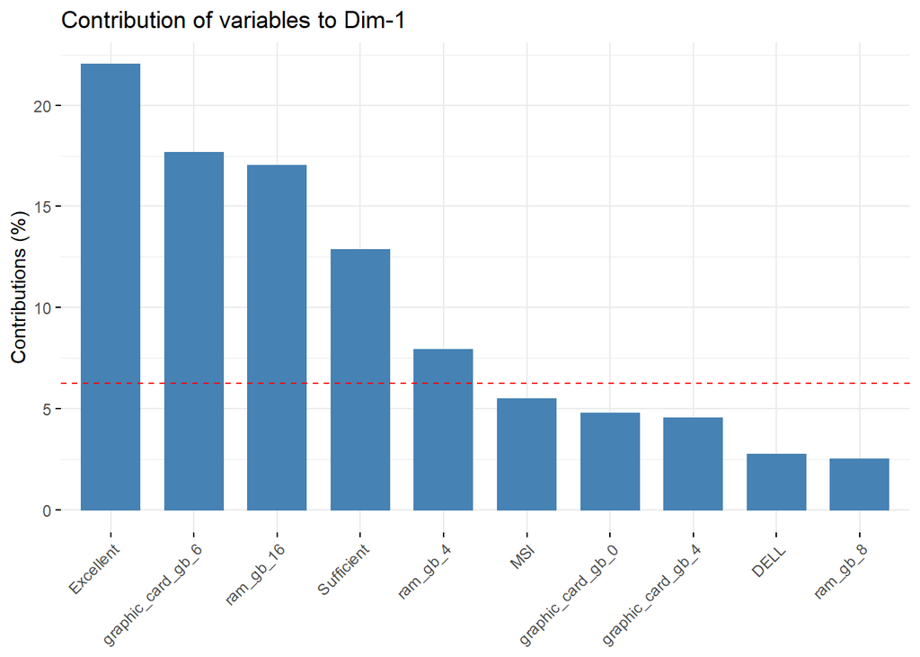

```r
fviz_contrib(res.MCA, choice = "var", axes = 1, top = 10)
```

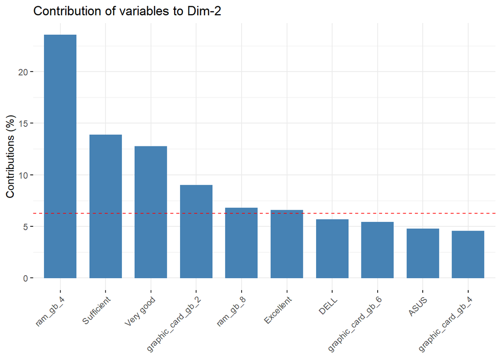

```r
fviz_contrib(res.MCA, choice = "var", axes = 2, top = 10)
```

**2nd dimensions vs 3rd dimension**

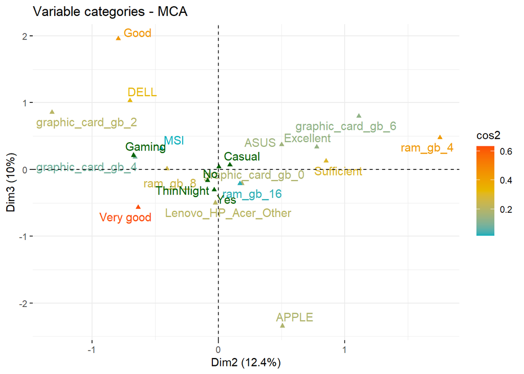

```r
fviz_mca_var(res.MCA, axes = c(2,3), col.var="cos2", gradient.cols = c("#00AFBB", "#E7B800", "#FC4E07"),
               repel = TRUE,
               ggtheme = theme_minimal())
```

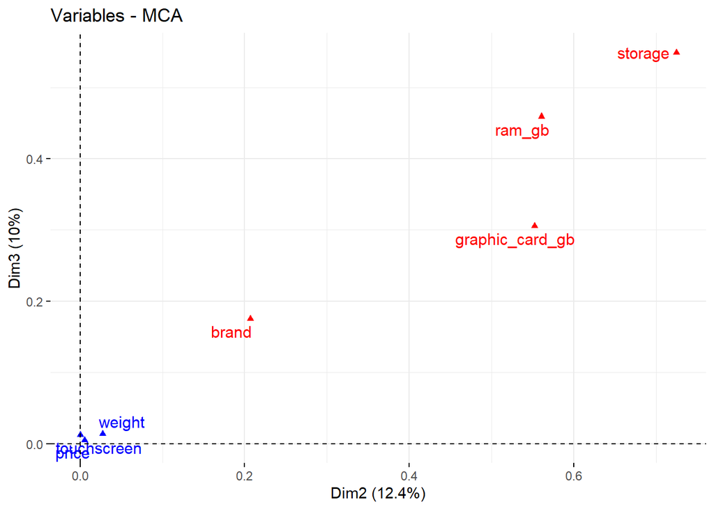

```r
fviz_mca_var(res.MCA, axes = c(2,3), choice = "mca.cor",
            repel = TRUE, # Avoid text overlapping (slow)
            ggtheme = theme_minimal())
```

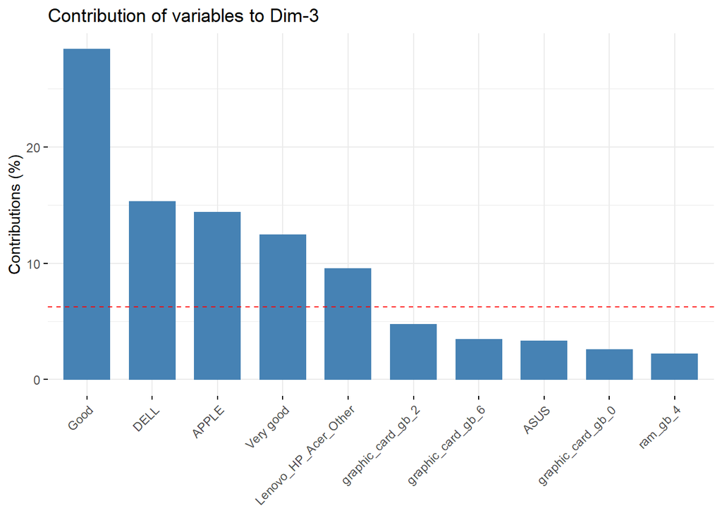

```r
fviz_contrib(res.MCA, choice = "var", axes = 3, top = 10)
```

MCA is not very useful because the percentage of variance explained in each dimension is very low.

# 8 Machine Learning models

## 8.1 Train-test sets

```r
set.seed(14153)
trainIndex <- createDataPartition(df_gr$price, p = 2/3, list=F)
training <- df_gr[trainIndex, ]
testing <- df_gr[-trainIndex, ]
```

```r
fitControl <- trainControl(method="repeatedcv", number=6, repeats=3)
```

In each cross validation, data is splitted into 6 parts (folds). 5 are used to create the model and 1 is for assessing the model.

## 8.2 Linear regression

Linear model with all the features. Remember they are all categorical, even though ram, graphic card, storage and weight could be treated as integers.

We want to model a numeric response variable depending on 9 categorical features. There are multiple options but the simplest one is a linear regression.

## 8.3 LM with cross validation

```r
set.seed(15514)
lm <- train(log(price)~., data=training, method = "lmStepAIC",
               trControl=fitControl, trace=F)
summary(lm)
```

```
##
## Call:
## lm(formula = .outcome ~ brandAPPLE + graphic_card_gb2 + graphic_card_gb4 +
##     graphic_card_gb6 + ram_gb8 + ram_gb16 + processor_brandAMD +
##     processor_brandOther + weightCasual + touchscreenYes + storageGood +
##     `storageVery good` + storageExcellent, data = dat)
##
## Residuals:
##     Min      1Q  Median      3Q     Max
## -0.7330 -0.1600 -0.0263  0.1367  1.0410
##
## Coefficients:
##                      Estimate Std. Error t value Pr(>|t|)
## (Intercept)           5.91567    0.03559 166.240  < 2e-16 ***
## brandAPPLE            0.66007    0.06753   9.774  < 2e-16 ***
## graphic_card_gb2      0.13996    0.04225   3.313 0.000981 ***
## graphic_card_gb4      0.18527    0.03207   5.777 1.23e-08 ***
## graphic_card_gb6      0.35298    0.05275   6.691 5.20e-11 ***
## ram_gb8               0.37494    0.03722  10.073  < 2e-16 ***
## ram_gb16              0.62485    0.04591  13.610  < 2e-16 ***
## processor_brandAMD   -0.11499    0.02539  -4.529 7.20e-06 ***
## processor_brandOther  0.21611    0.07619   2.836 0.004722 **
## weightCasual          0.03755    0.02395   1.568 0.117448
## touchscreenYes        0.27141    0.03470   7.821 2.45e-14 ***
## storageGood           0.19486    0.04326   4.504 8.05e-06 ***
## `storageVery good`    0.25877    0.02835   9.128  < 2e-16 ***
## storageExcellent      0.67507    0.04263  15.835  < 2e-16 ***
## ---
## Signif. codes:  0 '***' 0.001 '**' 0.01 '*' 0.05 '.' 0.1 ' ' 1
##
## Residual standard error: 0.2526 on 585 degrees of freedom
## Multiple R-squared:  0.7589, Adjusted R-squared:  0.7536
## F-statistic: 141.7 on 13 and 585 DF,  p-value: < 2.2e-16
```

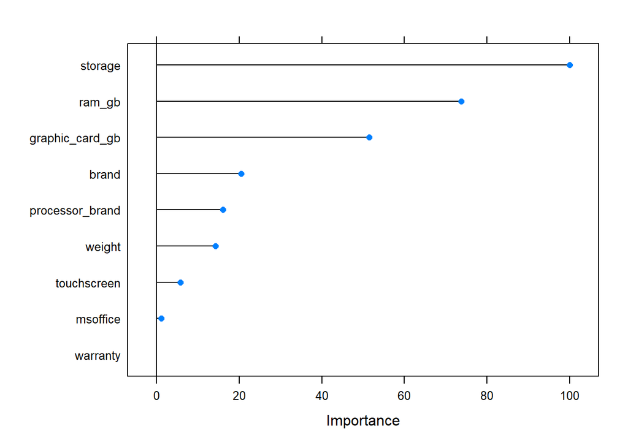

```r
plot(varImp(lm, scale=T))
```

```r
pred_lm <- predict(lm, newdata=testing)
```

The most important features to determine the price of a laptop are storage, ram and graphic card. The brand, processor and weight also have some importance in the linear regression.

### 8.3.1 Coefficients interpretation

```r
# Predicted price for the basic laptop
exp(summary(lm)$coefficients[1])
```

```
## [1] 370.802
```

The base laptop has this characteristics:

Brand = any but APPLE ; graphic_card_gb = 0; ram_gb = 4; processor_brand = Intel or APPLE;

weight = ThighNlight or Gaming ; touchscreen = No ; storage = Sufficient

These are also called the base category for each attribute.

Coefficients interpretation:

```r
(exp(summary(lm)$coefficients[-1, 1])-1)*100
```

```
##           brandAPPLE     graphic_card_gb2     graphic_card_gb4
##            93.493699            15.022347            20.354700
##     graphic_card_gb6              ram_gb8             ram_gb16
##            42.329852            45.490252            86.796094
##   processor_brandAMD processor_brandOther         weightCasual
##           -10.862836            24.123472             3.826126
##       touchscreenYes          storageGood   `storageVery good`
##            31.181627            21.513832            29.533738
##     storageExcellent
##            96.416328
```

Brand: APPLE has an increase in price of 93% respect any other laptop brand.

Graphic card: the price increases in 15% for 2GB graphic cards, in 20% for 4GB graphic cards and in 42% for 6GB graphic card laptops.

Ram: the price gets increased by 45% if the laptop has a 8GB ram, and by 86% if the ram has 16GB, instead the basic 4GB ram.

If the processor for the laptop is AMD instead of Intel or APPLE, the price for the laptop will be 10% lower. If it is another one, then the price increases in 24%.

If the weight is Casual the price gets increased by 3%.

A laptop with touchscreen is 31% more expensive.

Having a “Good” storage instead of just “Sufficient” increases the price by 21%. A very good storage is slightly more expensive with an increment of 29% and an Excellent storage gets really expensive, with an increment of 96%.

## 8.4 Lasso regression

Useful for multicollinearity data (if we consider that ram, graphic card and storage are very related).

Lambda: strength of the penalty on the coefficients.

```r
set.seed(63514)
lasso <- train(log(price)~., data=training, method="glmnet",
               tuneGrid=expand.grid(alpha=1, lambda=seq(0.0001,0.01,length=5)),
               trControl = fitControl)
lasso
```

```
## glmnet
##
## 599 samples
##   9 predictor
##
## No pre-processing
## Resampling: Cross-Validated (6 fold, repeated 3 times)
## Summary of sample sizes: 499, 499, 499, 499, 499, 500, ...
## Resampling results across tuning parameters:
##
##   lambda    RMSE       Rsquared   MAE
##   0.000100  0.2564475  0.7493439  0.1981323
##   0.002575  0.2562696  0.7496301  0.1975504
##   0.005050  0.2565098  0.7495056  0.1974532
##   0.007525  0.2572951  0.7486613  0.1977833
##   0.010000  0.2587319  0.7468256  0.1984686
##
## Tuning parameter 'alpha' was held constant at a value of 1
## RMSE was used to select the optimal model using the smallest value.
## The final values used for the model were alpha = 1 and lambda = 0.002575.
```

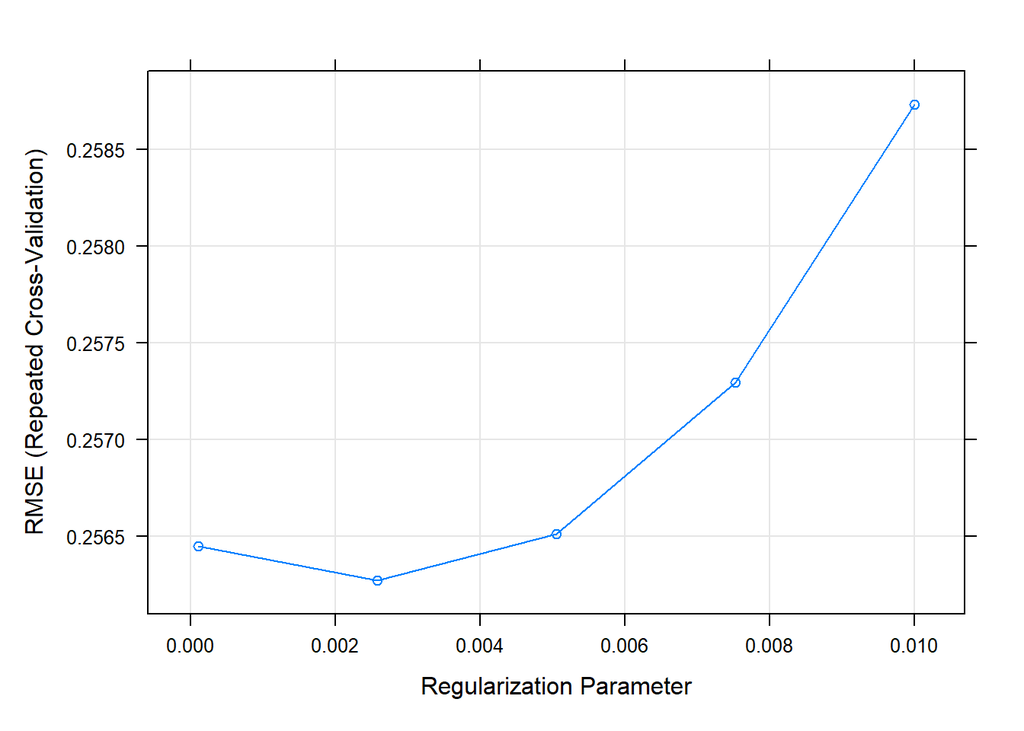

```r
plot(lasso)
```

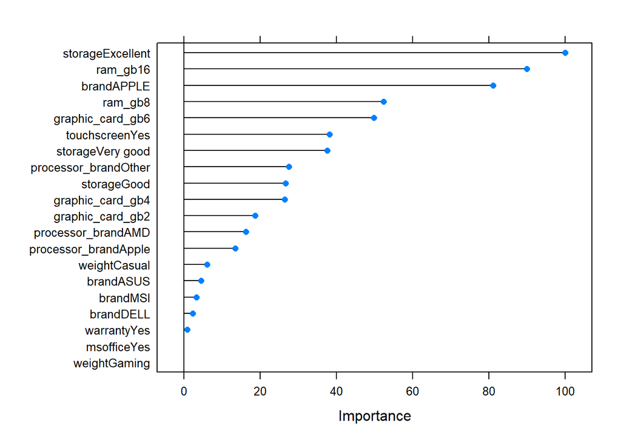

```r
plot(varImp(lasso, scale=T))
```

```r
pred_lasso <- predict(lasso, newdata=testing)
```

**Effect of Lambda**

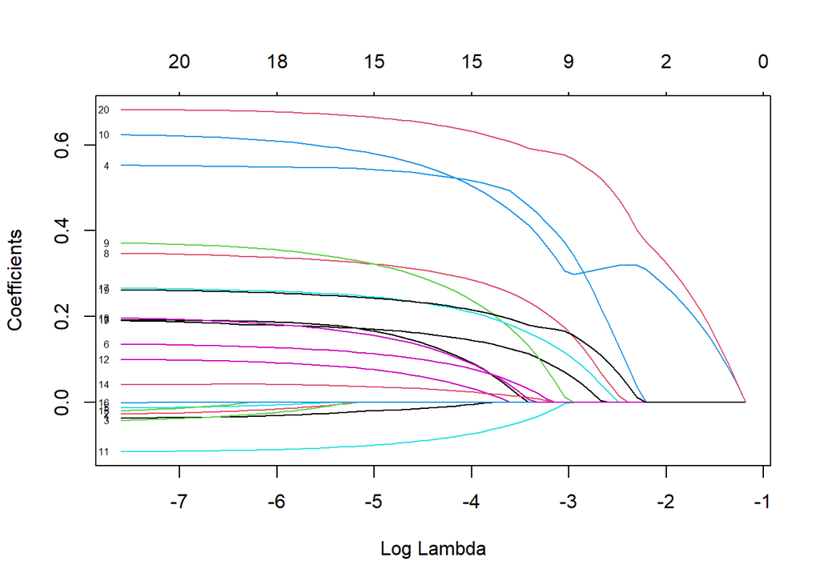

```r
plot(lasso$finalModel, xvar="lambda", label=T)
```

As lambda gets relaxed the coefficients starts to grow, which means that RMSE will become larger. Increasing lambda helps reduce the size of the coefficients.

Looking at the graph, when log lambda is close to -2, there are only 2 coefficient in the model.

```r
model_list <- list(Linear_model = lm, Lasso = lasso)
res <- resamples(model_list)
summary(res)
```

```
##
## Call:
## summary.resamples(object = res)
##
## Models: Linear_model, Lasso
## Number of resamples: 18
##
## MAE
##                   Min.   1st Qu.    Median      Mean   3rd Qu.      Max. NA's
## Linear_model 0.1719892 0.1939446 0.2004982 0.1988112 0.2069987 0.2228042    0
## Lasso        0.1776584 0.1864186 0.1937394 0.1975504 0.2078911 0.2317821    0
##
## RMSE
##                   Min.   1st Qu.    Median      Mean   3rd Qu.      Max. NA's
## Linear_model 0.2210584 0.2523753 0.2589931 0.2581980 0.2676345 0.2937272    0
## Lasso        0.2200587 0.2396589 0.2572852 0.2562696 0.2703540 0.3096915    0
##
## Rsquared
##                   Min.   1st Qu.    Median      Mean   3rd Qu.      Max. NA's
## Linear_model 0.6691988 0.7221591 0.7468990 0.7440237 0.7626005 0.8148150    0
## Lasso        0.6823503 0.7362919 0.7476098 0.7496301 0.7687647 0.8183809    0
```

Both methods give very similar results. Lasso has slightly better RMSE and Rsquared but also has a little more variance than linear model.

## 8.5 K-Nearest Neighbors

```r
set.seed(124151)
knn1 <- train(log(price)~., data=training, method = "knn", trControl=fitControl, tuneGrid=expand.grid(k=2:10))
knn1
```

```
## k-Nearest Neighbors
##
## 599 samples
##   9 predictor
##
## No pre-processing
## Resampling: Cross-Validated (6 fold, repeated 3 times)
## Summary of sample sizes: 499, 499, 499, 499, 499, 500, ...
## Resampling results across tuning parameters:
##
##   k   RMSE       Rsquared   MAE
##    2  0.2689298  0.7303206  0.1974944
##    3  0.2681093  0.7306606  0.1999624
##    4  0.2707648  0.7246239  0.2024184
##    5  0.2734199  0.7210351  0.2040102
##    6  0.2765791  0.7160731  0.2058901
##    7  0.2774719  0.7160519  0.2054118
##    8  0.2801078  0.7130378  0.2074757
##    9  0.2864436  0.7018064  0.2118179
##   10  0.2880671  0.6983014  0.2137873
##
## RMSE was used to select the optimal model using the smallest value.
## The final value used for the model was k = 3.
```

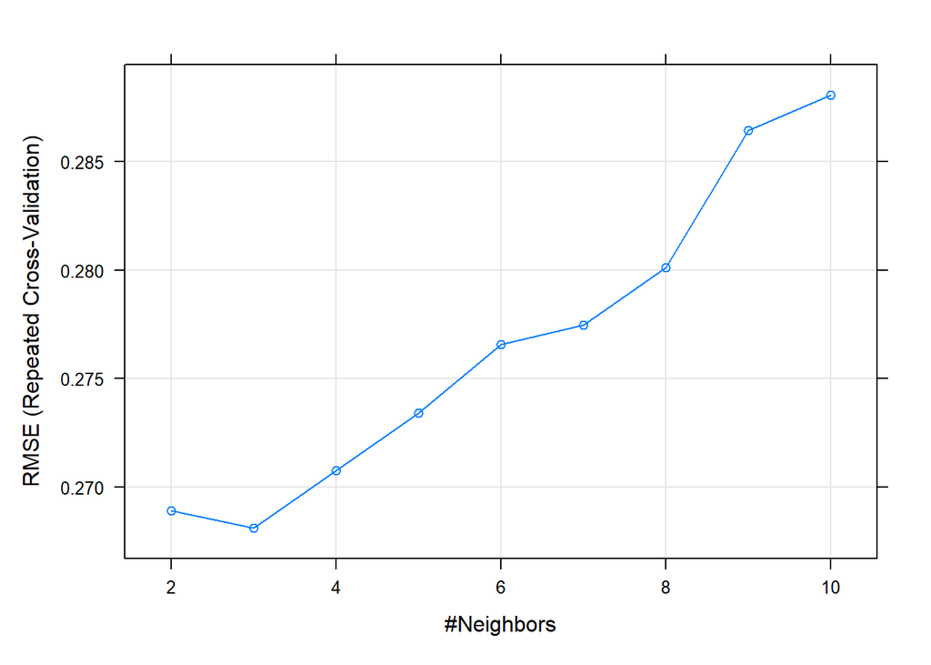

```r
plot(knn1)
```

If we were classifying, k would have to be non-multiple of the number of classes of the categorical predicted class.

Since we are doing regression, we can use any value of k.

k that maximized Rsquared is 3. If we use the 3 nearest laptops to determine the laptop price we get a model a little bit worse than linear model and Lasso regression.

```r
varImp(knn1)
```

```
## loess r-squared variable importance
##
##                 Overall
## storage         100.000
## ram_gb           73.772
## graphic_card_gb  51.481
## brand            20.496
## processor_brand  16.129
## weight           14.295
## touchscreen       5.855
## msoffice          1.186
## warranty          0.000
```

```r
pred_knn <- predict(knn1, newdata=testing)
```

The attributes that helps predict the price best with knn model are ram, storage and graphic card.

## 8.6 Random Forest

```r
set.seed(124151)
rf <- train(log(price)~., data=training, method = "rf", importance=T, trControl=fitControl,
             tuneGrid=expand.grid(mtry=seq(3,8,1)))
rf
```

```
## Random Forest
##
## 599 samples
##   9 predictor
##
## No pre-processing
## Resampling: Cross-Validated (6 fold, repeated 3 times)
## Summary of sample sizes: 499, 499, 499, 499, 499, 500, ...
## Resampling results across tuning parameters:
##
##   mtry  RMSE       Rsquared   MAE
##   3     0.2521993  0.7761652  0.1911472
##   4     0.2421457  0.7822705  0.1834170
##   5     0.2384908  0.7848274  0.1797075
##   6     0.2390508  0.7826373  0.1792296
##   7     0.2387201  0.7828705  0.1783727
##   8     0.2402947  0.7796340  0.1791686
##
## RMSE was used to select the optimal model using the smallest value.
## The final value used for the model was mtry = 5.
```

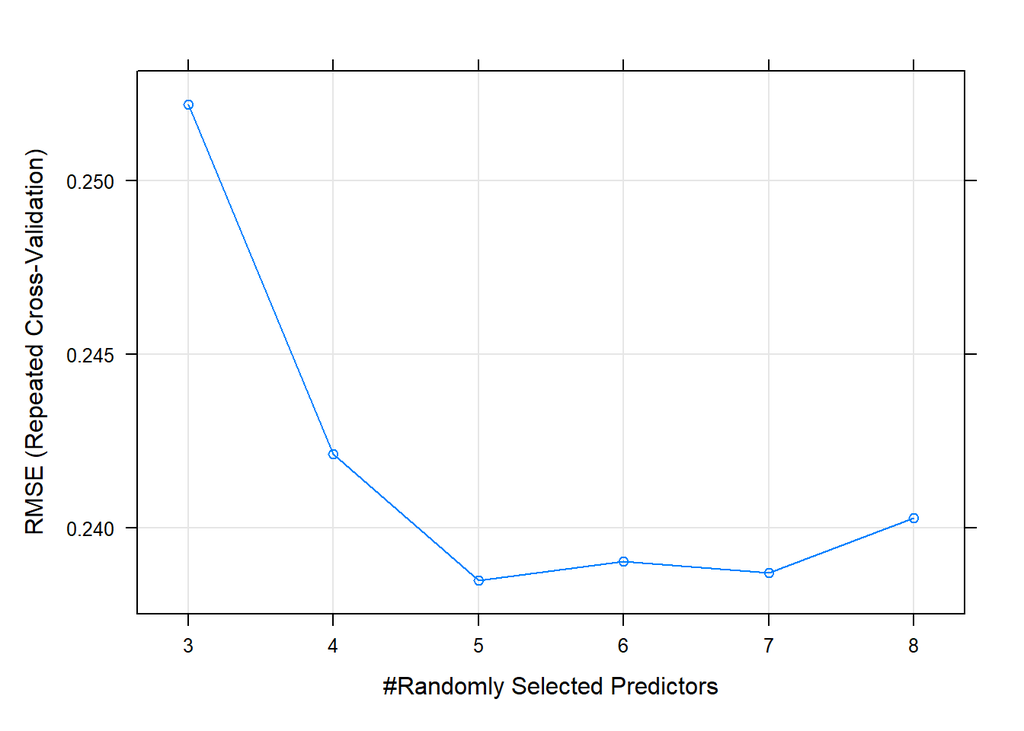

```r
plot(rf)
```

```r
varImp(rf)
```

```
## rf variable importance
##
##                      Overall
## ram_gb8              100.000
## touchscreenYes        92.284
## storageExcellent      87.701
## storageVery good      87.448
## ram_gb16              82.456
## graphic_card_gb2      58.177
## graphic_card_gb4      57.774
## processor_brandAMD    55.950
## msofficeYes           49.869
## brandASUS             47.433
## weightCasual          46.279
## brandAPPLE            45.411
## warrantyYes           41.371
## storageGood           38.162
## graphic_card_gb6      36.490
## brandDELL             36.363
## processor_brandApple  34.135
## weightGaming          12.787
## brandMSI               1.056
## processor_brandOther   0.000
```

```r
pred_rf <- predict(rf, newdata=testing)
```

## 8.7 Support Vector Machines

```r
set.seed(734363)
svm_Linear <- train(log(price)~., data=training, method = "svmLinear", trControl=fitControl,
             tuneGrid=expand.grid(C=seq(2.5,5,0.5)))
svm_Linear
```

```
## Support Vector Machines with Linear Kernel
##
## 599 samples
##   9 predictor
##
## No pre-processing
## Resampling: Cross-Validated (6 fold, repeated 3 times)
## Summary of sample sizes: 499, 499, 499, 500, 499, 499, ...
## Resampling results across tuning parameters:
##
##   C    RMSE       Rsquared   MAE
##   2.5  0.2630931  0.7375517  0.1950229
##   3.0  0.2631007  0.7375425  0.1950287
##   3.5  0.2631070  0.7375331  0.1950346
##   4.0  0.2631152  0.7375186  0.1950375
##   4.5  0.2630811  0.7375823  0.1950259
##   5.0  0.2631287  0.7374784  0.1950447
##
## RMSE was used to select the optimal model using the smallest value.
## The final value used for the model was C = 4.5.
```

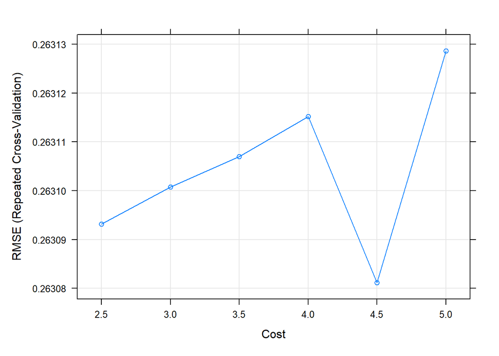

```r
plot(svm_Linear)
```

```r
set.seed(734363)
svm_Poly <- train(log(price)~., data=training, method = "svmPoly", trControl=fitControl,
             tuneGrid=expand.grid(degree=2:3, scale=c(0.05,0.1), C = c(0.05,0.1,0.5)))
svm_Poly
```

```
## Support Vector Machines with Polynomial Kernel
##
## 599 samples
##   9 predictor
##
## No pre-processing
## Resampling: Cross-Validated (6 fold, repeated 3 times)
## Summary of sample sizes: 499, 499, 499, 500, 499, 499, ...
## Resampling results across tuning parameters:
##
##   degree  scale  C     RMSE       Rsquared   MAE
##   2       0.05   0.05  0.2691686  0.7397323  0.1931407
##   2       0.05   0.10  0.2549203  0.7603158  0.1842054
##   2       0.05   0.50  0.2437306  0.7763666  0.1793777
##   2       0.10   0.05  0.2481668  0.7716669  0.1802924
##   2       0.10   0.10  0.2439255  0.7764893  0.1789886
##   2       0.10   0.50  0.2503527  0.7641804  0.1854748
##   3       0.05   0.05  0.2517422  0.7666036  0.1826019
##   3       0.05   0.10  0.2448630  0.7754742  0.1786129
##   3       0.05   0.50  0.2487552  0.7672635  0.1834926
##   3       0.10   0.05  0.2446649  0.7747654  0.1793210
##   3       0.10   0.10  0.2473096  0.7701163  0.1820404
##   3       0.10   0.50  0.2556082  0.7571926  0.1849440
##
## RMSE was used to select the optimal model using the smallest value.
## The final values used for the model were degree = 2, scale = 0.05 and C = 0.5.
```

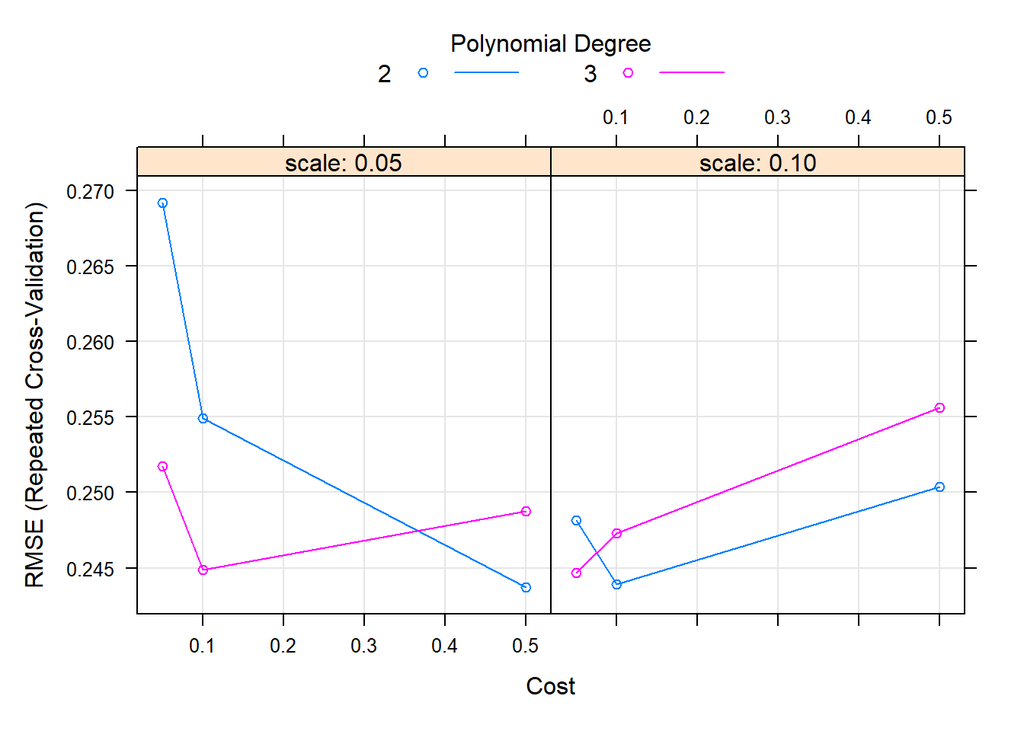

```r
plot(svm_Poly)
```

```r
set.seed(981284)
svm_Radial <- train(log(price)~., data=training, method = "svmRadial", trControl=fitControl,
             tuneGrid=expand.grid(C=c(1,2,3,4), sigma=c(.04,.08)))
svm_Radial
```

```
## Support Vector Machines with Radial Basis Function Kernel
##
## 599 samples
##   9 predictor
##
## No pre-processing
## Resampling: Cross-Validated (6 fold, repeated 3 times)
## Summary of sample sizes: 499, 499, 499, 499, 500, 499, ...
## Resampling results across tuning parameters:
##
##   C  sigma  RMSE       Rsquared   MAE
##   1  0.04   0.2417146  0.7765815  0.1748059
##   1  0.08   0.2395168  0.7813129  0.1742643
##   2  0.04   0.2365086  0.7853453  0.1731853
##   2  0.08   0.2377315  0.7836295  0.1735713
##   3  0.04   0.2371859  0.7844592  0.1741654
##   3  0.08   0.2388383  0.7820258  0.1746435
##   4  0.04   0.2385757  0.7824733  0.1751405
##   4  0.08   0.2407068  0.7792863  0.1762052
##
## RMSE was used to select the optimal model using the smallest value.
## The final values used for the model were sigma = 0.04 and C = 2.
```

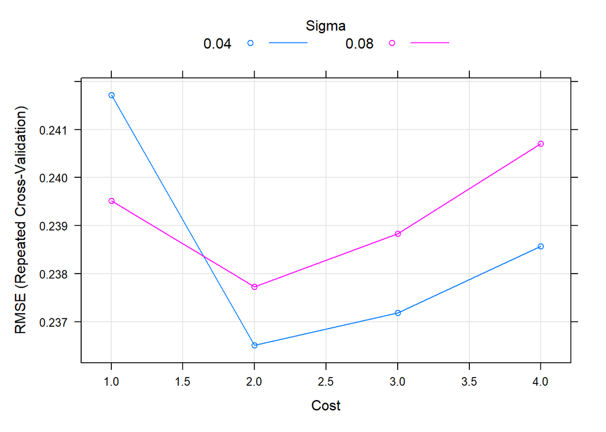

```r
plot(svm_Radial)
```

# 9 Comparing all models

```r
model_list <- list(Linear_model = lm, Lasso = lasso, Knn = knn1, RF = rf,
                   SVMLinear = svm_Linear, SVMPoly = svm_Poly, SVMRadial = svm_Radial)
res <- resamples(model_list)
summary(res)
```

```
##
## Call:
## summary.resamples(object = res)
##
## Models: Linear_model, Lasso, Knn, RF, SVMLinear, SVMPoly, SVMRadial
## Number of resamples: 18
##
## MAE
##                   Min.   1st Qu.    Median      Mean   3rd Qu.      Max. NA's
## Linear_model 0.1719892 0.1939446 0.2004982 0.1988112 0.2069987 0.2228042    0
## Lasso        0.1776584 0.1864186 0.1937394 0.1975504 0.2078911 0.2317821    0
## Knn          0.1693642 0.1851707 0.1984958 0.1999624 0.2193447 0.2293332    0
## RF           0.1523569 0.1704487 0.1768266 0.1797075 0.1948944 0.2009988    0
## SVMLinear    0.1709269 0.1843538 0.1898907 0.1950259 0.2041199 0.2304068    0
## SVMPoly      0.1496083 0.1704503 0.1767483 0.1793777 0.1864456 0.2111705    0
## SVMRadial    0.1458184 0.1576798 0.1712909 0.1731853 0.1910681 0.2002666    0
##
## RMSE
##                   Min.   1st Qu.    Median      Mean   3rd Qu.      Max. NA's
## Linear_model 0.2210584 0.2523753 0.2589931 0.2581980 0.2676345 0.2937272    0
## Lasso        0.2200587 0.2396589 0.2572852 0.2562696 0.2703540 0.3096915    0
## Knn          0.2267340 0.2399232 0.2766371 0.2681093 0.2908149 0.3078501    0
## RF           0.2079319 0.2199231 0.2319133 0.2384908 0.2596272 0.2711785    0
## SVMLinear    0.2310962 0.2433069 0.2563036 0.2630811 0.2761403 0.3227595    0
## SVMPoly      0.2099791 0.2253308 0.2335337 0.2437306 0.2576286 0.3023571    0
## SVMRadial    0.1977977 0.2197834 0.2370836 0.2365086 0.2532843 0.2717856    0
##
## Rsquared
##                   Min.   1st Qu.    Median      Mean   3rd Qu.      Max. NA's
## Linear_model 0.6691988 0.7221591 0.7468990 0.7440237 0.7626005 0.8148150    0
## Lasso        0.6823503 0.7362919 0.7476098 0.7496301 0.7687647 0.8183809    0
## Knn          0.6400790 0.7021696 0.7207688 0.7306606 0.7647783 0.8068928    0
## RF           0.7344335 0.7633453 0.7924930 0.7848274 0.8094069 0.8204473    0
## SVMLinear    0.6333578 0.7066108 0.7580650 0.7375823 0.7766801 0.7929393    0
## SVMPoly      0.6853514 0.7470820 0.7890580 0.7763666 0.8131738 0.8410255    0
## SVMRadial    0.7127021 0.7491801 0.7953438 0.7853453 0.8119688 0.8639317    0
```

The models that fits this data better are the Random Forest and SVM with a radial kernel.

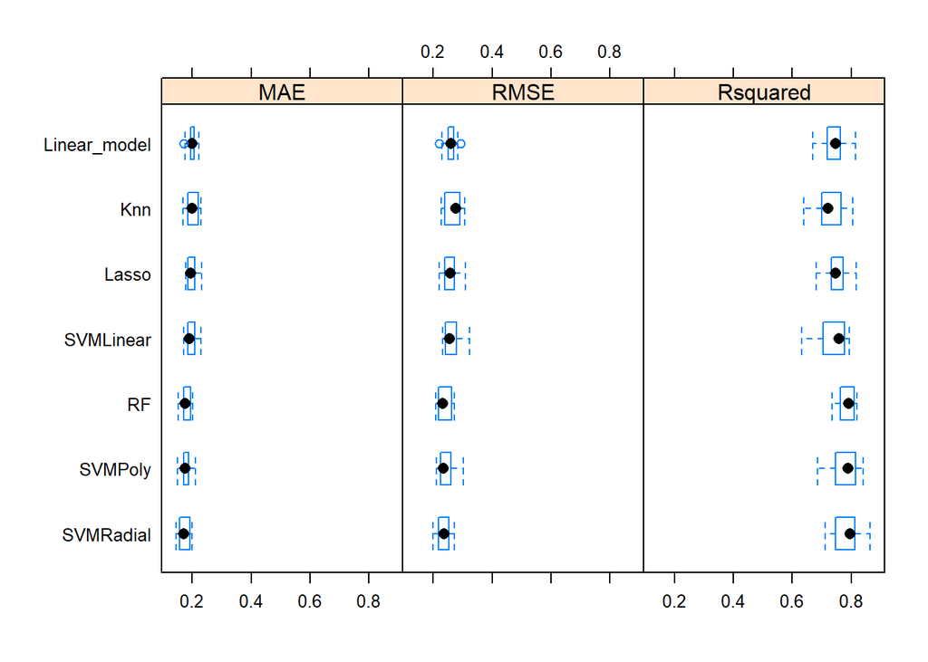

```r
bwplot(res)
```

```r
saveRDS(svm_Radial, "final_model.rds")
```

SVM has de downside of having null interpretability, while for Random Forest we can check which features where more used (more important) when creating multiple decision trees.

# 10 Conclusions

The features that inflate the price of laptops are storage, ram and graphic cards. Some brands add value to its laptops (for instance, Apple). Furthermore, touchscreen laptops are more expensive.

This study would have been much better with more information about the processor, for example, knowing the generation of Intel processors. Unfortunately, the data set has a lot of wrong values in this variable.

With this data, it is possible to study which laptops are liked most with a variable called star rating (that goes from 0 to 5). This will be my next project.